# Descriptive Statistics

Ihor Markevych

11/11/2019

# Read data

The file Beatles.csv presents information on the 12 studio albums by The Beatles. Specifically, it gives the lengths, in seconds, of the songs, by album: Please Please Me (PPM), With The Beatles (WTB), A Hard Day’s Night (HDN), Beatles for Sale (BFS), Help! (HLP), Rubber Soul (RBS), Revolver (RVR), Sgt. Pepper’s Lonely Hearts Club Band (SPL), The Beatles (TBS), Yellow Submarine (YSB), Abbey Road (ABR), and Let It Be (LIB). The albums are ordered by release date (i.e. PPM was the first album released, WTB was the second album released, etc.). The song-lengths are arranged for each album in increasing order.

```r
d <- read.csv('Beatles.csv')
d
```

```
##    PPM WTB HDN BFS HLP RBS RVR SPL TBS YSB ABR LIB
## 1  110 108 109 106 114 125 121  80  52 130  23  41
## 2  112 119 119 121 123 136 121 124 100 158  66  49
## 3  119 124 131 122 124 138 127 157 105 194  72 145
## 4  124 128 132 123 125 139 129 157 123 207  91 152
## 5  125 129 135 132 128 143 135 158 124 227  96 172
## 6  125 133 140 135 137 147 145 163 137 388 117 187
## 7  142 136 140 143 138 147 149 164 138  NA 125 213
## 8  144 147 144 150 148 150 150 166 144  NA 146 217
## 9  146 149 152 151 149 153 157 169 148  NA 165 217
## 10 147 152 153 153 153 162 158 210 160  NA 171 227
## 11 153 156 158 153 155 163 159 217 162  NA 183 232
## 12 158 167 158 153 156 164 177 307 163  NA 185 241
## 13 175 167 166 163 173 170 181 333 163  NA 207  NA
## 14 177 182  NA 175 190 202 181  NA 167  NA 213  NA
```

[output cut: 16 more lines]

# Functions

## Create barchart

```r
plotBarChart <- function(d,
                         title = rownames(d)[1],
                         yLab = 'seconds',
                         xLab = 'Album'){
  title <- title
  rownames(d) <- 'value'
  d <- data.frame(t(d))
  ggplot(d, aes(x = factor(rownames(d), levels = rownames(d)), y = value)) +
    theme_bw() +
    theme(panel.grid.major.x = element_blank(),
          panel.grid.minor = element_blank(),
          plot.title = element_text(hjust = 0.5),
          panel.border = element_blank()) +
    labs(title = title) +
    xlab(xLab) +
    ylab(yLab) +
    geom_col(fill='lightgrey', color='black')
}
```

# Descriptive Statistics

## Median song length

### Values

Determine the median song length of each album.

```r
medians <- data.frame(t(apply(d, 2, median, na.rm = TRUE)))
rownames(medians) <- 'Median_Song_Length'
medians
```

```
##                    PPM   WTB HDN   BFS HLP   RBS   RVR SPL TBS   YSB ABR
## Median_Song_Length 143 141.5 140 146.5 143 148.5 149.5 164 174 200.5 165
##                    LIB
## Median_Song_Length 200
```

### Chart

Construct a bar graph with album name on the horizontal axis and median song length on the vertical axis.

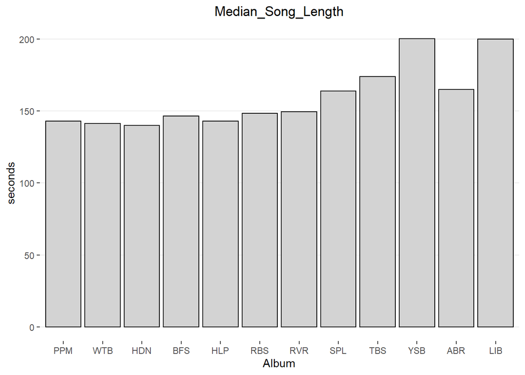

```r
plotBarChart(medians)
```

### Interpretation

Interpret your graph, keeping in mind that the albums are ordered by release date.

As it can be seen, most of the albums had approximately same median song length (except for LIB and YSB which have bigger values). Beatles started making longer songs later in their career.

## Range of song lengths

### Values

Determine the range of song lengths for each album.

```r
ranges <- data.frame(t(apply(d, 2,
                           function(x)
                             range(x, na.rm = TRUE)[2] -
                             range(x, na.rm = TRUE)[1])))
rownames(ranges) <- 'Range_of_Song_Length'
ranges
```

```
##                      PPM WTB HDN BFS HLP RBS RVR SPL TBS YSB ABR LIB
## Range_of_Song_Length  67  74  57  69  76  77  60 253 441 258 444 200
```

### Chart

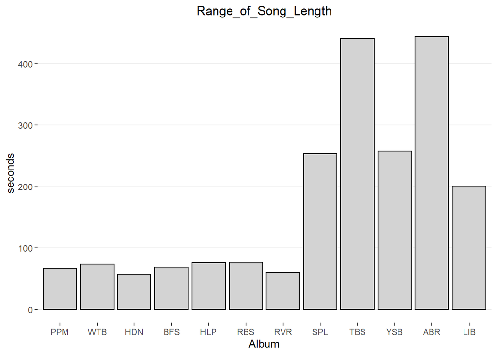

```r
plotBarChart(ranges)
```

### Interpretation

Interpret your graph, keeping in mind that the albums are ordered by release date.

It can be seen that last five albums had much greater range of song lengths compared to other albums. TBS and ABR stands out a lot.  
In terms of time evolution we may assume that Beatles started from very unranged songs, but went up to bigger range of length later.

## Quartiles of song length

Find the quartiles of song length for each album.

### Built-in quartiles

```r
builtQuartiles <- data.frame(apply(d, 2, quantile, na.rm = TRUE))
builtQuartiles
```

```
##         PPM    WTB HDN    BFS    HLP    RBS    RVR SPL    TBS   YSB ABR
## 0%   110.00 108.00 109 106.00 114.00 125.00 121.00  80  52.00 130.0  23
## 25%  124.25 128.25 132 125.25 125.75 140.00 130.50 157 145.00 167.0  96
## 50%  143.00 141.50 140 146.50 143.00 148.50 149.50 164 174.00 200.5 165
## 75%  151.50 155.00 153 153.00 154.50 162.75 158.75 210 207.75 222.0 207
## 100% 177.00 182.00 166 175.00 190.00 202.00 181.00 333 493.00 388.0 467
##         LIB
## 0%    41.00
## 25%  150.25
## 50%  200.00
## 75%  219.50
## 100% 241.00
```

### Custom quartiles

```r
getQuartiles <- function(d){
  d <- d[!is.na(d)]
  c(d[ceiling(length(d) / 4)],
       d[ceiling(length(d) / 2)],
       d[ceiling(length(d) * 3 / 4)]
       )
}

quartiles <- data.frame(apply(d, 2, getQuartiles))
rownames(quartiles) <- c('Q1', 'Q2', 'Q3')
quartiles
```

```
##    PPM WTB HDN BFS HLP RBS RVR SPL TBS YSB ABR LIB
## Q1 124 128 132 123 125 139 129 157 144 158  96 145
## Q2 142 136 140 143 138 147 149 164 174 194 165 187
## Q3 153 156 153 153 155 163 159 210 212 227 207 217
```

### Groups of quartiles

```r
getQuartilesGroups <- function(d){
  d <- d[!is.na(d)]
  res <- data.frame(
      d[1 : ceiling(length(d) / 4)],
      d[(floor(length(d) / 4) + 1) : ceiling(length(d) / 2)],
      d[(floor(length(d) / 2) + 1) : ceiling(length(d) * 3 / 4)]
    )
  colnames(res) <- c('Q1', 'Q2', 'Q3')
  res
}

for(col in colnames(d)){
  cat(col, '\n')
  print(getQuartilesGroups(d[, col]))
  cat('=====================\n')
}
```

```
## PPM
##    Q1  Q2  Q3
## 1 110 124 144
## 2 112 125 146
## 3 119 125 147
## 4 124 142 153
## =====================
## WTB
##    Q1  Q2  Q3
## 1 108 128 147
## 2 119 129 149
## 3 124 133 152
## 4 128 136 156
## =====================
## HDN
##    Q1  Q2  Q3
## 1 109 132 140
## 2 119 135 144
## 3 131 140 152
## 4 132 140 153
## =====================
## BFS
##    Q1  Q2  Q3
## 1 106 123 150
## 2 121 132 151
## 3 122 135 153
## 4 123 143 153
## =====================
## HLP
##    Q1  Q2  Q3
## 1 114 125 148
## 2 123 128 149
## 3 124 137 153
## 4 125 138 155
## =====================
## RBS
##    Q1  Q2  Q3
## 1 125 139 150
## 2 136 143 153
## 3 138 147 162
```

[output cut: 31 more lines]

```
## =====================
## ABR
##   Q1  Q2  Q3
## 1 23  96 165
## 2 66 117 171
## 3 72 125 183
## 4 91 146 185
## 5 96 165 207
## =====================
## LIB
##    Q1  Q2  Q3
## 1  41 152 213
## 2  49 172 217
## 3 145 187 217
## =====================
```

## Interquartile Range (IQR)

### Values

Determine the IQR of song lengths for each album.

```r
IQR <- quartiles['Q3',] - quartiles['Q1',]
rownames(IQR) <- 'IQR'
IQR
```

```
##     PPM WTB HDN BFS HLP RBS RVR SPL TBS YSB ABR LIB
## IQR  29  28  21  30  30  24  30  53  68  69 111  72
```

### Chart

Construct a bar graph with album name on the horizontal axis and IQR of song lengths on the vertical axis.

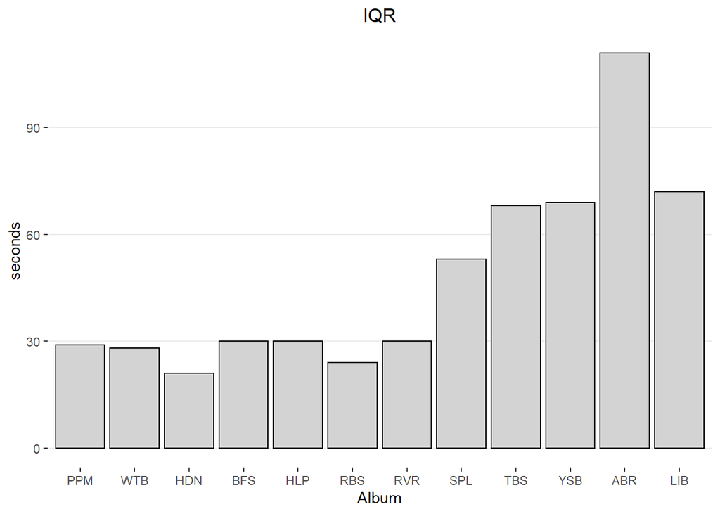

```r
plotBarChart(IQR)
```

### Interpretation

Interpret your graph, keeping in mind that the albums are ordered by release date.

As in range case, last albums had much greater IQR of song lengths compared to other albums. Since IQR is also connected to range, our previous assumption is corroborated (in terms of time evolution we may assume that Beatles started from very unranged songs, but went up to higher range of length).

## Lower and upper limits

### Values

```r
limits <- rbind(quartiles['Q1',] - 1.5 * IQR, quartiles['Q3',] + 1.5 * IQR)
rownames(limits) <- c('Lower_Limit', 'Upper_Limit')
limits
```

```
##               PPM WTB   HDN BFS HLP RBS RVR   SPL TBS   YSB   ABR LIB
## Lower_Limit  80.5  86 100.5  78  80 103  84  77.5  42  54.5 -70.5  37
## Upper_Limit 196.5 198 184.5 198 200 199 204 289.5 314 330.5 373.5 325
```

### Outliers

#### Logical matrix

```r
outliers <- data.frame(mapply(function(x, l) x < l, d, limits['Lower_Limit',])) |
  data.frame(mapply(function(x, l) x > l, d, limits['Upper_Limit',]))
```

#### Values

```r
outliersValues <- d[outliers]
outliersValues <- outliersValues[!is.na(outliersValues)]
outliersByAlbum <- list()
for(value in outliersValues){
  outliersByAlbum[[colnames(d)[apply(d, 2, function(x) value %in% x)]]] <- c(outliersByAlbum[[colnames(d)[apply(d, 2, function(x) value %in% x)]]], value)
}

for (album in attributes(outliersByAlbum)$names){
  cat('Album', album, 'contains next potential outliers:', paste0(paste0(outliersByAlbum[[album]], collapse = ', '), '.\n'))
}
```

```
## Album RBS contains next potential outliers: 202.
## Album SPL contains next potential outliers: 307, 333.
## Album TBS contains next potential outliers: 493.
## Album YSB contains next potential outliers: 388.
## Album ABR contains next potential outliers: 467.
```

#### Albums with outliers

Next albums contain potential outliers:

```r
colnames(d)[which(apply(outliers, 2, any))]
```

```
## [1] "RBS" "SPL" "TBS" "YSB" "ABR"
```

## Plots and outliers

### Boxplot with `ggplot`

For each album, construct a boxplot of the song lengths, and interpret your results in terms of the variation of the song lengths. Are the outliers the same as what you determined in previous part?

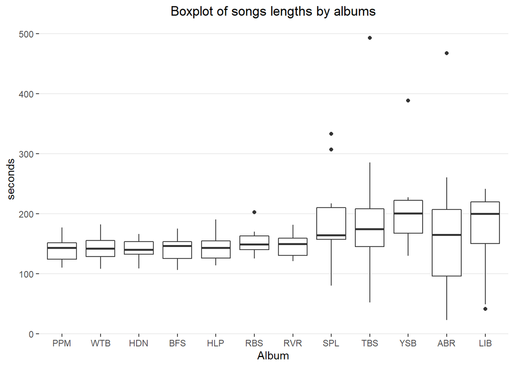

```r
ggplot(stack(d), aes(x = ind, y = values)) +
  theme_bw() +
  theme(panel.grid.major.x = element_blank(),
        panel.grid.minor = element_blank(),
        plot.title = element_text(hjust = 0.5),
        panel.border = element_blank()) +
  labs(title = 'Boxplot of songs lengths by albums') +
  xlab('Album') +
  ylab('seconds') +
  geom_boxplot()
```

### Outliers with `boxplot()`

Whiskers extend to the most extreme data point which is no more than `coef` times the length of the box away from the box.

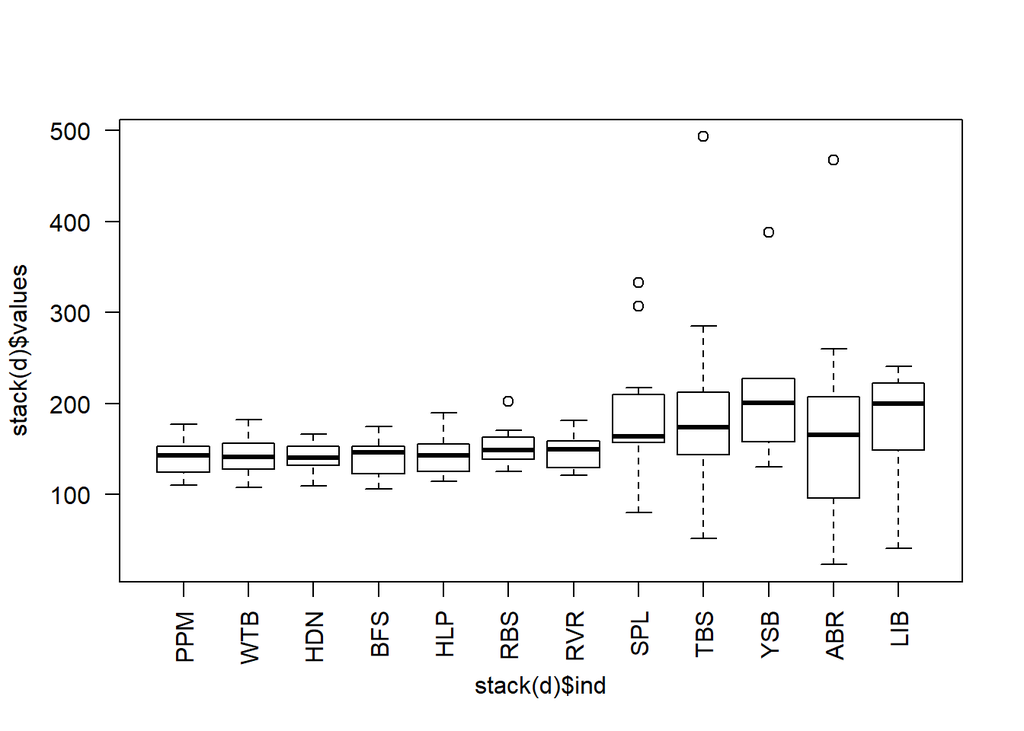

```r
boxplot(stack(d)$values ~ stack(d)$ind, las=2)
```

```r
for (col in colnames(d)){
  outs <- boxplot.stats(d[, col], coef = 1.5)$out
  if (length(outs > 0)){
    print(outs)
  }
}
```

```
## [1] 202
## [1] 307 333
## [1] 493
## [1] 388
## [1] 467
```

#### Outliers comparison

Most of the outliers with `ggplot` are same, except for LIB one, which, as it can be seen, is very close to lower limit. This is explained by the fact that IQR is calculated from slightly different quartiles (weighted).  
For `boxplot()` outliers are same.

### Violin plot

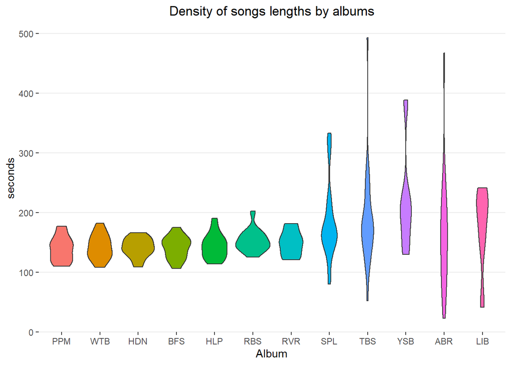

```r
ggplot(stack(d), aes(x = ind, y = values, fill = ind)) +
  theme_bw() +
  theme(panel.grid.major.x = element_blank(),
        panel.grid.minor = element_blank(),
        plot.title = element_text(hjust = 0.5),
        panel.border = element_blank(),
        legend.position = "none") +
  labs(title = 'Density of songs lengths by albums') +
  xlab('Album') +
  ylab('seconds') +
  geom_violin()
```

### Combined

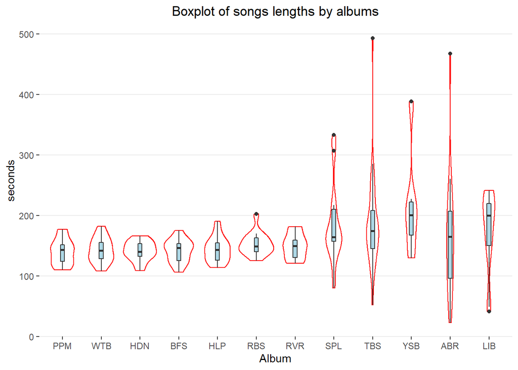

```r
ggplot(stack(d), aes(x = ind, y = values)) +
  theme_bw() +
  theme(panel.grid.major.x = element_blank(),
        panel.grid.minor = element_blank(),
        plot.title = element_text(hjust = 0.5),
        panel.border = element_blank()) +
  labs(title = 'Boxplot of songs lengths by albums') +
  xlab('Album') +
  ylab('seconds') +
  geom_violin(color = 'red') +
  geom_boxplot(width = 0.1, fill = 'lightblue')
```